# R/Bioconductor入门

ligc

2020/4/11

##hello world

```r
cat("hello world")
```

```
## hello world
```

```r
print("hello world")
```

```
## [1] "hello world"
```

```r
"hello world"
```

```
## [1] "hello world"
```

##基本运算

```r
.4 - .7 + .3 #不是0
```

```
## [1] 5.551115e-17
```

```r
x <- 100
sqrt(x)
```

```
## [1] 10
```

```r
y = exp(x)
y
```

```
## [1] 2.688117e+43
```

```r
exp(log(x))
```

```
## [1] 100
```

```r
##在赋值语句中，尽量只使用"<-"。"="应该只出现在函数的参数赋值中
##同一行如果想写多个命令，需要使用";"来分隔

## .4 - .7 + .3为什么会不等于零呢？

##计算机在保存一个浮点数a时，是由两个数m和e来表示：a = m x be。m是有位数限制的，这就决定了等号右边不可能完全等于等号左边的a。所以浮点数在计算机中的保存只是它的一个近似数.

floor(29/50*50) #floor数字取整
```

```
## [1] 28
```

```r
floor(29*50/50)
```

```
## [1] 29
```

```r
##原因
op <- options(digits=22) ##设置显示精度为22位
29/50
```

```
## [1] 0.57999999999999996
```

```r
.58*50
```

```
## [1] 28.999999999999996
```

```r
29*50/50
```

```
## [1] 29
```

```r
options(op) ##恢复之前的设置
##.58在计算机中只能以近似数0.579999999999999960032来代替
##所以在R的计算中，应该尽量避免先做除法运算
```

```r
## 变量中保存一系列数字
a <- c(5, 2, 3, 4)
## c是combine缩写，可以简单地理解为将数据分组在一起
a + 5
```

```
## [1] 10  7  8  9
```

```r
a - 10
```

```
## [1] -5 -8 -7 -6
```

```r
c <- (a + sqrt(a))/exp(a); c
```

```
## [1] 0.04875624 0.46206356 0.23559494 0.10989383
```

```r
a * c
```

```
## [1] 0.2437812 0.9241271 0.7067848 0.4395753
```

```r
b <- sort(a, decreasing=TRUE); b
```

```
## [1] 5 4 3 2
```

```r
max(a)
```

```
## [1] 5
```

```r
mean(a)
```

```
## [1] 3.5
```

```r
fivenum(a) ## (minimum, lower-hinge, median, upper-hinge, maximum)
```

```
## [1] 2.0 2.5 3.5 4.5 5.0
```

```r
## 在R中，逻辑运算符(logical operator)有!, &, &&, |, ||, ,isTRUE等等。&与&&, |与||有什么区别呢？在R中将&和|称为短逻辑符，&&及||称为长逻辑符。长逻辑符只比较左边和右边的第一个元素，而短逻辑符会一一比较所有的元素。
a<-c(TRUE, FALSE, TRUE, FALSE)
b<-c(FALSE, FALSE, TRUE, TRUE)
c<-c(TRUE, FALSE, FALSE, FALSE)
a & b
```

```
## [1] FALSE FALSE  TRUE FALSE
```

```r
a && b
```

```
## [1] FALSE
```

```r
a || b
```

```
## [1] TRUE
```

```r
a | c
```

```
## [1]  TRUE FALSE  TRUE FALSE
```

```r
## 因为R是不需要声明变量的,使用ls()函数来显示当前搜索路径下所有的变量名，然后再决定应该使用很什么样的新变量名
ls()
```

```
## [1] "a"  "b"  "c"  "op" "x"  "y"
```

##条件控制语句

基本的条件语句有： if, ifelse, switch, for, while, next, break

```r
hairLength <- 25
waistHeight <- 110
height <- 168
marryMe <- FALSE
if(hairLength >= height - waistHeight)
  { marryMe <- TRUE
                   }
ifelse(marryMe, "YES", "NO")
```

```
## [1] "NO"
```

```r
day <- 0
if(!marryMe){
  while(hairLength < height - waistHeight){
    day <- day + 1
    hairLength <- hairLength + .1
  }
  marryMe <- TRUE
}
day
```

```
## [1] 330
```

```r
hairLength <- 25
marryMe <- FALSE
wait <- 100 * 365
for(day in 1:wait){
  if(hairLength >= height - waistHeight){
    marryMe <- TRUE
    break
  }else{
    if(runif(1) < 0.5){
      next
    }
    hairLength <- hairLength + .1
  }
}
day
```

```
## [1] 635
```

##R/Bioconductor的书写规范

```
退格与列
使用4个空格来替换tab
每一行不超过80个字符

变量名
使用匈牙利命名法：以一个或者多个小写字母起始，接着首字母大写的单词缩写，中间不使用除字母与数字以外的其它字符。比如someVar1。
函数名
使用匈牙利命名法：以一个或者多个小写字母起始，接着首字母大写的单词缩写，中间不使用除字母与数字以外的其它字符。

避免使用'.'，比如some.func

合理使用空格
在逗号后一定使用空格。比如a, b, c。而不应该是a,b,c。这样做有利于系统自动换行。

在函数传递参数时等号（=）左右不使用空格。比如someFunc(a=1, b=2)，而不应该是someFunc(a = 1, b = 2)。

在逻辑运算符左右使用空格，比如a == b。

在赋值运算符左右使用空格，比如a <- 2。

注释
使用连续两个##开始注释

注释需要和代码的退格保持一致

其它
使用'<-'而不是'='作为赋值符号
```

##R软件包

```
所谓包(Package)，就是基于R系统的标准化的代码，数据及文档的文件集合
提供可用于安装的带有版本控制的包的网站被称为安装源(Repository)
安装好的包将被放在一个指定的目录下。这个目录被称为库(Library)。当需要使用到某一个包的时候，通过运行library()函数来加载软件包，其过程就是到库中去寻找需要加载的软件包，并将其命名空间加载至当前运行环境下
```

```r
## 加载名为lattice的软件包
library(lattice)

## 查看当前运行环境
```

[output not shown]

```r
## BiocManager::install("trackViewer") ##安装trackViewer软件包
library(trackViewer) ##加载trackViewer软件包
## chooseBioCmirror()
```

##获取R/Bioconductor帮助

```r
##（1）对于已知名称的函数，欲了解该函数（例如查询函数solve）的详细使用方法，可以用“?solve”或者“help(solve)”来获取当前搜索路径中函数solve的帮助。

# help(solve)
## 对于由特殊字符或某些关键词（例如if）指定的功能，这些参数必须用单引号或双引号括起来，例如：

## ?`[`

## 使用help函数或者“?”得到帮助信息的前提是该函数所在的扩展包已经加载。

##（2）对于未知名称的函数，希望通过关键词搜索，可以使用“??”或者“help.search ()”来找到与搜索关键词相关的所有函数。

## ??motif
```

##R Data structure

###Abstract of data structure

在R中，基本的数据类型被分为character, double, integer以及logical。double及integer类型又被统一称为numeric类型。如果数据都为character，或者double，或者integer，或者logical，就被称为同质的(Homogeneous)，否则被称为异质的(Heterogeneous)

| 维度 | 同质的 | 异质的 |
| --- | --- | --- |
| 1维 | Atomic vector | List |
| 2维 | Matrix | Data frame |
| 3维 | Array |  |

对于1维的Atomic vector，它的长度可以是0。任何单个的数据类型，都被视为atomic vector，其长度为1

```r
##长度为0的atomic vector
a <- integer(0)
length(a)
```

```
## [1] 0
```

```r
##单个的数据，被视为长度为1的atomic vector
b <- "a"
length(b)
```

```
## [1] 1
```

```r
##查看a和b的封装类
class(a)
```

```
## [1] "integer"
```

```r
class(pi)
```

```
## [1] "numeric"
```

```r
class(b)
```

```
## [1] "character"
```

```r
##查看a和pi的模式
mode(a)
```

```
## [1] "numeric"
```

```r
mode(pi)
```

```
## [1] "numeric"
```

```r
##查看a和pi的存贮模式
storage.mode(a)
```

```
## [1] "integer"
```

```r
storage.mode(pi)
```

```
## [1] "double"
```

```r
##查看a和b的类型
typeof(a)
```

```
## [1] "integer"
```

```r
typeof(b)
```

```
## [1] "character"
```

```r
typeof(pi)
```

```
## [1] "double"
```

```r
##查看预存数据letters
str(letters)
```

```
##  chr [1:26] "a" "b" "c" "d" "e" "f" "g" "h" "i" "j" "k" "l" "m" "n" "o" "p" ...
```

####Vectors

无论是atomic vector还是list，都属于vector 除了vector中保存的数据以外，它还有三个属性：typeof() (是什么), length() (有多少元素)和attributes() (有哪些注释数据)

#####Atomic vector Atomic vector常见的是由logical, integer, double, 或者character组成，很罕见的是由raw或者complex组成。

```r
x <- c(1.0, 3.5, 5.6)
i <- c(1L, 2L, 10L) ## L后缀便于R自动识别输入的数字为整型
b <- c(TRUE, FALSE, T, F) ## 通常而言，在标准的代码书写过程中应该避免使用不完整的缩写T和F。
ch <- c("who", "am", "I")
```

c()函数都是可以圈套使用的，但其结果不会产生分层，而全部会展平为一层。比如

```r
c(1, c(2, 3)) == c(1, 2, 3)
```

```
## [1] TRUE TRUE TRUE
```

```r
a <- 1:3 ## 冒号（：）是seq()函数的缩写, 用于生成序列数
b <- seq(1:3)
typeof(a)
```

```
## [1] "integer"
```

```r
is.integer(a)
```

```
## [1] TRUE
```

```r
is.numeric(a)
```

```
## [1] TRUE
```

```r
length(a)
```

```
## [1] 3
```

```r
attributes(a)
```

[output not shown]

```r
names(a) <- letters[1:3]
attributes(a)
```

```
## $names
## [1] "a" "b" "c"
```

```r
length(LETTERS)
```

```
## [1] 26
```

```r
typeof(LETTERS)
```

```
## [1] "character"
```

当不同类型的数据使用c()函数创建atomic vector时，因为atomic vector的元素都必须是同质的，所以系统会依照character, double, integer, logical的顺序对数据类型进行转换

```r
c(9, "a", 1.5, FALSE) ##全部转换为character
```

```
## [1] "9"     "a"     "1.5"   "FALSE"
```

```r
c(9, 1.5, FALSE) ##全部转换为double
```

```
## [1] 9.0 1.5 0.0
```

```r
c(FALSE, 9) ##全部转换为integer
```

```
## [1] 0 9
```

```r
a <- c(4, 2, 1, 3)
b <- sort(a)
b
```

```
## [1] 1 2 3 4
```

######Factor Factor是R中非常具有特点的一类atomic vector 它的创建分为三个步骤，1，将输入的数据转换成character型；2，对所有的水平进行排序（可能是指定的排序，或者自然排序)，将排序后的水平保存在levels中；3，使用levels中的水平序列号重新编码输入的元素。

```r
a <- factor(c(2, 1, 5, 10, 5))
a
```

```
## [1] 2  1  5  10 5
## Levels: 1 2 5 10
```

```r
levels(a)
```

```
## [1] "1"  "2"  "5"  "10"
```

```r
a[4] ## a的第四个元素
```

```
## [1] 10
## Levels: 1 2 5 10
```

```r
as.numeric(a)
```

```
## [1] 2 1 3 4 3
```

```r
as.numeric(as.character(a)) ##将a正确地还原为原始数据
```

```
## [1]  2  1  5 10  5
```

```r
b <- factor(letters[c(2, 1, 5, 10, 5)])
b
```

```
## [1] b a e j e
## Levels: a b e j
```

```r
levels(b)
```

```
## [1] "a" "b" "e" "j"
```

```r
b[4]
```

```
## [1] j
## Levels: a b e j
```

```r
as.numeric(b) ##与之前的强制转换比较，就发现，这里得到的数字只是重新编码后的数字。
```

```
## [1] 2 1 3 4 3
```

```r
## Factor的值必须是levels中包含的值，否值无法对其编码。

a <- factor(1:4)
a[4] <- 5 ## 会得到一个警告
a
```

```
## [1] 1    2    3    <NA>
## Levels: 1 2 3 4
```

```r
## 正确的做法是先改变其levels，然后再变更其值
levels(a) <- c(levels(a), 5)
a[4] <- 5
a
```

```
## [1] 1 2 3 5
## Levels: 1 2 3 4 5
```

```r
## 如果想修改factor中所有等于某值的数据为level中不存在的另一数值，应该直接修改其levels。
a <- factor(c(letters[1:5], letters[5:1]))
a
```

```
##  [1] a b c d e e d c b a
## Levels: a b c d e
```

```r
a[2] <- "a" ##是level中存在的值，是可以的。
a
```

```
##  [1] a a c d e e d c b a
## Levels: a b c d e
```

```r
levels(a)[3] <- "z"
a
```

```
##  [1] a a z d e e d z b a
## Levels: a b z d e
```

```r
x <- sample(1:10, 100, replace=TRUE); x
```

```
##   [1] 10 10  4  4  3  1  4  1  3  1  8  2  1  8  4  4  1  9  3  4  4  4  9  3  8
##  [26] 10  7  7  1  9  9  6  4  4  9  6  9  3  4  2  6  7  7  2  6  3  2  1  3 10
##  [51]  8 10  3  3  5  2  7  1  6  8  6  8  6  3  2  6  4  5  6  5  4  3 10  8  6
##  [76]  3  7  3  2  4  9  4 10  9  1  2 10  4 10  5  4  2  8  9  9  6  4  2  4 10
```

```r
y <- 1:100
split(y, x)
```

```
## $`1`
## [1]  6  8 10 13 17 29 48 58 85
##
## $`2`
##  [1] 12 40 44 47 56 65 79 86 92 98
##
## $`3`
##  [1]  5  9 19 24 38 46 49 53 54 64 72 76 78
##
## $`4`
##  [1]  3  4  7 15 16 20 21 22 33 34 39 67 71 80 82 88 91 97 99
##
## $`5`
## [1] 55 68 70 90
##
## $`6`
##  [1] 32 36 41 45 59 61 63 66 69 75 96
##
## $`7`
## [1] 27 28 42 43 57 77
##
## $`8`
## [1] 11 14 25 51 60 62 74 93
##
## $`9`
##  [1] 18 23 30 31 35 37 81 84 94 95
##
## $`10`
##  [1]   1   2  26  50  52  73  83  87  89 100
```

####List

同属于vector的list也是一维的，但是其元素可以是任何一种vector，当然也就包括了list。可以用目录来类比list。目录下可以存放不同的文件，包括目录，list也是一样的，只不过文件变成了vector

```r
a <- list(1:3, letters[1:3], c(FALSE, TRUE), c(1, 1.0)); str(a)
```

```
## List of 4
##  $ : int [1:3] 1 2 3
##  $ : chr [1:3] "a" "b" "c"
##  $ : logi [1:2] FALSE TRUE
##  $ : num [1:2] 1 1
```

```r
x <- list(list(list())); str(x); is.recursive(x)
```

```
## List of 1
##  $ :List of 1
##   ..$ : list()
```

```
## [1] TRUE
```

```r
x <- list(list(1, 2), c(3, 4))
y <- c(list(1, 2), c(3, 4)) # y会是一个展平为一层的list
str(x)
```

```
## List of 2
##  $ :List of 2
##   ..$ : num 1
##   ..$ : num 2
##  $ : num [1:2] 3 4
```

```r
str(y)
```

```
## List of 4
##  $ : num 1
##  $ : num 2
##  $ : num 3
##  $ : num 4
```

```r
a <- c(1:3, letters[1:3], c(FALSE, TRUE), list(1, 1.0)); str(a)
```

```
## List of 10
##  $ : int 1
##  $ : int 2
##  $ : int 3
##  $ : chr "a"
##  $ : chr "b"
##  $ : chr "c"
##  $ : logi FALSE
##  $ : logi TRUE
##  $ : num 1
##  $ : num 1
```

```r
## 从本质上看，list是一种有长度的链表数据，每一个元素其实都是一个指针，它可以指向任何一种数据结构
```

####List与atomic vector的区别与联系

`Atomic vector和list一样都可以使用索引号或者名称来访问其元素，但方法会略有 不同`

```r
a <- list(num=8, alphabet=letters[1:3],
          logi=TRUE, num=c(1, 1.0))
class(a[[1]])
```

```
## [1] "numeric"
```

```r
class(a[1])
```

```
## [1] "list"
```

```r
is.atomic(a[1])
```

```
## [1] FALSE
```

```r
is.atomic(a[[1]])
```

```
## [1] TRUE
```

```r
is.list(a[1])
```

```
## [1] TRUE
```

```r
names(a)
```

```
## [1] "num"      "alphabet" "logi"     "num"
```

```r
a["alphabet"] # 取子集
```

```
## $alphabet
## [1] "a" "b" "c"
```

```r
a[["alphabet"]] # 访问元素
```

```
## [1] "a" "b" "c"
```

```r
a$alphabet
```

```
## [1] "a" "b" "c"
```

```r
b <- c(letters[1:8],'x')
names(b) <- LETTERS[10:18]
is.atomic(b)
```

```
## [1] TRUE
```

```r
b[1] # 取子集
```

```
##   J
## "a"
```

```r
b[9] # 取子集
```

```
##   R
## "x"
```

```r
b[[9]] # 访问元素
```

```
## [1] "x"
```

```r
b["R"] # 访问元素
```

```
##   R
## "x"
```

```r
tryCatch(b$L, ## 会得到一个错误
         error = function(e) e)
```

```
## <simpleError in b$L: $ operator is invalid for atomic vectors>
```

```r
## list访问元素的方式为'[['或者'$'，取子集的方式为'['；atomic vector访问元素和取子集的方式均为'['。list和atomic vector都可以通过索引号和名称访问其元素。
```

如果想去除atomic vector中的某些元素，可以使用’-‘号；如果想去除list中的某些元素，可以使用’-’号或者赋值为NULL。也可以使用TRUE/FALSE来取舍。

```r
a <- 3:6
a[-c(1,4)]
```

```
## [1] 4 5
```

```r
tryCatch(a[2] <- NULL, ## 会得到一个错误
         error = function(e) e)
```

```
## <simpleError in a[2] <- NULL: 更换参数长度为零>
```

```r
a[c(TRUE, FALSE, TRUE, FALSE)]
```

```
## [1] 3 5
```

```r
a <- as.list(a); a
```

```
## [[1]]
## [1] 3
##
## [[2]]
## [1] 4
##
## [[3]]
## [1] 5
##
## [[4]]
## [1] 6
```

```r
a[-c(1,4)]
```

```
## [[1]]
## [1] 4
##
## [[2]]
## [1] 5
```

```r
tryCatch(a[[-3]], ## 会得到一个错误
         error = function(e) e)
```

```
## <simpleError in a[[-3]]: attempt to select more than one element in get1index <real>>
```

```r
a[c(TRUE, FALSE,T,F)]
```

```
## [[1]]
## [1] 3
##
## [[2]]
## [1] 5
```

```r
a[[1]] <- NULL;a
```

```
## [[1]]
## [1] 4
##
## [[2]]
## [1] 5
##
## [[3]]
## [1] 6
```

###二维数据结构：Matrices和DataFrame

####Matrix

简单的讲，给atomic vector加上维度信息，它就变成了array。如果维度信息是二维的，它就是matrix。也就是说，matrix只是array的一个特例，而array是从atomic vector扩展而来的

```r
vec <- 1:12
mat <- matrix(vec, ncol=3, nrow=4,byrow = T) ##ncol == number of column, nrow == number of row
mat
```

```
##      [,1] [,2] [,3]
## [1,]    1    2    3
## [2,]    4    5    6
## [3,]    7    8    9
## [4,]   10   11   12
```

```r
## 使用访问atomic vector的方法访问matrix
mat[7]
```

```
## [1] 8
```

```r
## 使用访问matrix的方法访问mat
mat[3, 2]
```

```
## [1] 8
```

```r
## 访问第二列
mat[, 2]
```

```
## [1]  2  5  8 11
```

```r
## 访问第一行
class(mat[1, ])
```

```
## [1] "integer"
```

```r
## 访问第三列，但保持结果为matrix的形式
class(mat[, 3, drop=FALSE])
```

```
## [1] "matrix"
```

```r
## 改变第3行第2列的元素值为20
mat[3, 2] <- 20
dim(mat) ##matrix维度
```

```
## [1] 4 3
```

```r
nrow(mat) ## 有几行
```

```
## [1] 4
```

```r
ncol(mat) ## 几列
```

```
## [1] 3
```

```r
length(mat) ## 这是继承的vector的属性
```

```
## [1] 12
```

```r
rownames(mat) <- letters[1:nrow(mat)] ## 行号
colnames(mat) <- LETTERS[1:ncol(mat)] ## 列号
mat
```

```
##    A  B  C
## a  1  2  3
## b  4  5  6
## c  7 20  9
## d 10 11 12
```

```r
## 构建一个array
arr <- array(vec, c(2, 3, 2))
arr
```

```
## , , 1
##
##      [,1] [,2] [,3]
## [1,]    1    3    5
## [2,]    2    4    6
##
## , , 2
##
##      [,1] [,2] [,3]
## [1,]    7    9   11
## [2,]    8   10   12
```

```r
dim(arr)
```

```
## [1] 2 3 2
```

```r
## 合并matrix时，使用c()函数会将matrix视为atomic vector，所以得到还是一个atomic vector。如果这时还需要保持matrix的维度，那就需要使用到rbind()/cbind()

mat1 <- matrix(1:4, ncol=2)
mat2 <- matrix(4:1, ncol=2)
mat3 <- c(mat1,mat2)
mat3
```

```
## [1] 1 2 3 4 4 3 2 1
```

```r
rbind(mat1, mat2) ## mat2接在mat1的下方
```

```
##      [,1] [,2]
## [1,]    1    3
## [2,]    2    4
## [3,]    4    2
## [4,]    3    1
```

```r
cbind(mat1, mat2) ## mat2接在mat1的右侧
```

```
##      [,1] [,2] [,3] [,4]
## [1,]    1    3    4    2
## [2,]    2    4    3    1
```

```r
## matrix转置使用t()函数(transpose)。

mat <- matrix(1:12, ncol=3)
mat; t(mat)
```

```
##      [,1] [,2] [,3]
## [1,]    1    5    9
## [2,]    2    6   10
## [3,]    3    7   11
## [4,]    4    8   12
```

```
##      [,1] [,2] [,3] [,4]
## [1,]    1    2    3    4
## [2,]    5    6    7    8
## [3,]    9   10   11   12
```

####DataFrame

Data frame是R中最常被用到的数据结构。Data frame就是由一系列长度相等的vectors构成。它继承了vector的所有方法，包括atomic vector和list的方法，比如访问某一列可以使用’$’符号。它是2维的，它一样也有和matrix相同的方法，比如colnames(), rownames(), rbind(), cbind(), dim(), ncol(), nrow()等。

```r
df <- data.frame(A=1:3, B=letters[1:3])
df
```

```
##   A B
## 1 1 a
## 2 2 b
## 3 3 c
```

```r
str(df)
```

```
## 'data.frame':    3 obs. of  2 variables:
##  $ A: int  1 2 3
##  $ B: Factor w/ 3 levels "a","b","c": 1 2 3
```

```r
df$A ##以列名访问元素
```

```
## [1] 1 2 3
```

```r
df[["B"]]
```

```
## [1] a b c
## Levels: a b c
```

```r
df[1, ] ##第一行
```

```
##   A B
## 1 1 a
```

```r
df[, 2] ##第二列
```

```
## [1] a b c
## Levels: a b c
```

```r
cbind(df, C=0)
```

```
##   A B C
## 1 1 a 0
## 2 2 b 0
## 3 3 c 0
```

```r
rbind(df, data.frame(A=4, B="d")) ## 注意，在rbind时，需要保持列名一致
```

```
##   A B
## 1 1 a
## 2 2 b
## 3 3 c
## 4 4 d
```

```r
dim(df)
```

```
## [1] 3 2
```

```r
## df的第二列原本输入的时候是character，但是在构建data.frame时，自动被转换为factors。这并不一定是我们需要的。如果想保留它原本的character属性，需要加上stringsAsFactors=FALSE参数

df <- data.frame(A=1:3, B=letters[1:3], stringsAsFactors=FALSE)
str(df)
```

```
## 'data.frame':    3 obs. of  2 variables:
##  $ A: int  1 2 3
##  $ B: chr  "a" "b" "c"
```

```r
## 使用List构建data.frame
df <- data.frame(A=1:3)
df$B <- list(1, 1:2, letters[1:3])
df
```

```
##   A       B
## 1 1       1
## 2 2    1, 2
## 3 3 a, b, c
```

```r
## 如果直接使用list来构建data.frame，却不能直接成功。

## tryCatch(data.frame(A=1:3, B=list(1, 1:2, letters[1:3])),error = function(e) e)

## 使用I()函数来整合它。这里的I是AsIs的意思，即指输入是什么就是什么。

data.frame(A=1:3, B=I(list(1, 1:2, letters[1:3])))
```

```
##   A       B
## 1 1       1
## 2 2    1, 2
## 3 3 a, b, c
```

#### Matrix, DataFrame与List

list既然只是保存了一系列的指针,否可以用这些指针指向一个Matrix, DataFrame

```r
mat <- matrix(1:12, ncol=3)
df <- data.frame(A=1:3, B=letters[1:3], stringsAsFactors=FALSE)
lst <- list(mat=mat, df=df)
str(lst)
```

```
## List of 2
##  $ mat: int [1:4, 1:3] 1 2 3 4 5 6 7 8 9 10 ...
##  $ df :'data.frame': 3 obs. of  2 variables:
##   ..$ A: int [1:3] 1 2 3
##   ..$ B: chr [1:3] "a" "b" "c"
```

```r
## 在使用list时需要记住的是，它是一种消耗内存的数据结构，如果数据量非常大，需要尽量避免使用list结构。
```

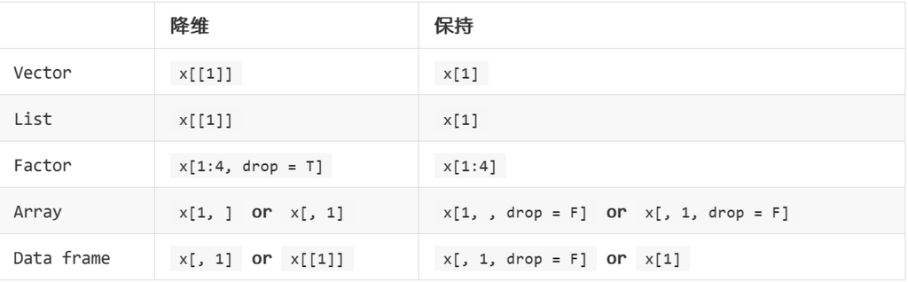

取值与赋值

##输入与输出

```r
## 使用getwd()来获取当前目录。

path <- getwd() ##获取当前工作目录
basename(path)
```

```
## [1] "R_bioinfo"
```

```r
path <- "test"
dir.create(path) ## 创建一个目录
setwd(path) ## 变更工作目录
setwd("../") ## 变更目录至上一级
unlink(path) ## 删除目录
dir() ##查看当前目录
```

```
##  [1] "1.RData"                          "all1.RData"
##  [3] "ds1.Rdata"                        "footer.html"
##  [5] "header.html"                      "index.html"
##  [7] "index.Rmd"                        "LRT1.xls"
##  [9] "mat1.rda"                         "palma-4902795_1920.jpg"
## [11] "R_Bioconductor入门.html"          "R_Bioconductor入门.log"
## [13] "R_Bioconductor入门.Rmd"           "R_Bioconductor入门.tex"
## [15] "R_bioinfo.Rproj"                  "results.csv"
## [17] "RNA-seq-data-analysis.docx"       "RNA-seq-data-analysis.html"
## [19] "RNA-seq-data-analysis.log"        "RNA-seq-data-analysis.Rmd"
## [21] "RNA-seq-data-analysis.tex"        "Snipaste_2020-03-04_20-36-21.png"
## [23] "style.css"                        "test"
## [25] "test.txt"                         "test.txt2"
## [27] "testXLS.csv"
```

R的输入输出主要有几个类型：文本文件，xls文件，数据库文件，R文件，其它统计软件来源的文件。

###文本文件

```r
test.txt <- data.frame(ArrayDataFile=paste("GSM28676", 1:8, sep=""),
                       FactorValue=rep(c("control", "mutation"), each=4))
test.txt
```

```
##   ArrayDataFile FactorValue
## 1     GSM286761     control
## 2     GSM286762     control
## 3     GSM286763     control
## 4     GSM286764     control
## 5     GSM286765    mutation
## 6     GSM286766    mutation
## 7     GSM286767    mutation
## 8     GSM286768    mutation
```

```r
## 将其写入到临时文件中
tftsv <- tempfile()
tfcsv <- tempfile()
write.table(test.txt, tftsv, quote=FALSE, sep="\t", row.names=FALSE)
write.csv(test.txt, tfcsv, row.names=FALSE)

## 现在需要把它读入R，可以使用read.table函数。read.table还有几个快捷的形式，比如read.delim,read.delim2,read.csv,read.csv2
tsv1 <- read.delim(tftsv)
tsv1
```

```
##   ArrayDataFile FactorValue
## 1     GSM286761     control
## 2     GSM286762     control
## 3     GSM286763     control
## 4     GSM286764     control
## 5     GSM286765    mutation
## 6     GSM286766    mutation
## 7     GSM286767    mutation
## 8     GSM286768    mutation
```

```r
tsv2 <- read.table(tftsv, quote="", sep="\t", header=TRUE)
identical(tsv1, tsv2) ##测试读取的是否相同
```

```
## [1] TRUE
```

```r
csv1 <- read.csv(tfcsv)
csv1
```

```
##   ArrayDataFile FactorValue
## 1     GSM286761     control
## 2     GSM286762     control
## 3     GSM286763     control
## 4     GSM286764     control
## 5     GSM286765    mutation
## 6     GSM286766    mutation
## 7     GSM286767    mutation
## 8     GSM286768    mutation
```

```r
csv2 <- read.table(tfcsv, sep=",", header=TRUE)
identical(csv1, csv2)
```

```
## [1] TRUE
```

```r
## 只需要读取文件的前几行
read.delim(tftsv, nrows=5)
```

```
##   ArrayDataFile FactorValue
## 1     GSM286761     control
## 2     GSM286762     control
## 3     GSM286763     control
## 4     GSM286764     control
## 5     GSM286765    mutation
```

```r
## 需要读取文件中间的几行，那么可以在上面的函数当中加入skip及nrows参数
read.delim(tftsv, header=F, nrows=4, skip=3)
```

```
##          V1       V2
## 1 GSM286763  control
## 2 GSM286764  control
## 3 GSM286765 mutation
## 4 GSM286766 mutation
```

###R文件

读就用load，写就用save。 保存当前对话中所有的数据

```r
save(list=ls(all=TRUE), file="all.RData") ##有一个快捷函数为save.image()
save.image(file = "all1.RData")
rm(list=ls()) ##删除对话中所有的对象
ls()
```

```
## character(0)
```

```r
## 读取之前保存的数据
load("all.RData")
ls()
```

```
##  [1] "a"           "arr"         "b"           "c"           "ch"
##  [6] "csv1"        "csv2"        "day"         "df"          "hairLength"
## [11] "height"      "i"           "lst"         "marryMe"     "mat"
## [16] "mat1"        "mat2"        "mat3"        "op"          "path"
## [21] "test.txt"    "tfcsv"       "tftsv"       "tsv1"        "tsv2"
## [26] "vec"         "waistHeight" "wait"        "x"           "y"
```

```r
unlink("all.RData") ## 删除刚写入的文件


## 保存当前对话中的mat1，使用最大的压缩比

save("test.txt", file="mat1.rda", compress="bzip2", compression_level=9)
file.info("mat1.rda")$size ##文件的大小
```

```
## [1] 278
```

```r
object.size(mat1) ## 在内存中的大小
```

```
## 232 bytes
```

```r
## 查看可用的数据
#data()
## 调用mtcars数据
data(mtcars)
head(mtcars)
```

```
##                    mpg cyl disp  hp drat    wt  qsec vs am gear carb
## Mazda RX4         21.0   6  160 110 3.90 2.620 16.46  0  1    4    4
## Mazda RX4 Wag     21.0   6  160 110 3.90 2.875 17.02  0  1    4    4
## Datsun 710        22.8   4  108  93 3.85 2.320 18.61  1  1    4    1
## Hornet 4 Drive    21.4   6  258 110 3.08 3.215 19.44  1  0    3    1
## Hornet Sportabout 18.7   8  360 175 3.15 3.440 17.02  0  0    3    2
## Valiant           18.1   6  225 105 2.76 3.460 20.22  1  0    3    1
```

###数据库文件

DBI被广泛地应用于Bioconductor的注释文件操作。使用DBI获取数据分为四步：建立联接，发送查寻语句，读取数据，关闭联接。数据库写入只是查寻语句不同，并且不需要再用fetch读取数据而已.

```r
library(DBI)
library(RSQLite)

dbPath <- system.file("extdata", "org.Hs.eg.sqlite", package="org.Hs.eg.db")
drv <- dbDriver("SQLite")
db <- dbConnect(drv, dbPath)
db
```

```
## <SQLiteConnection>
##   Path: C:\Users\15544\Documents\R\win-library\3.6\org.Hs.eg.db\extdata\org.Hs.eg.sqlite
##   Extensions: TRUE
```

```r
dbListTables(db) ## 等同于MySQL函数 show tables;
```

```
##  [1] "accessions"            "alias"                 "chrlengths"
##  [4] "chromosome_locations"  "chromosomes"           "cytogenetic_locations"
##  [7] "ec"                    "ensembl"               "ensembl2ncbi"
## [10] "ensembl_prot"          "ensembl_trans"         "gene_info"
## [13] "genes"                 "go"                    "go_all"
## [16] "go_bp"                 "go_bp_all"             "go_cc"
## [19] "go_cc_all"             "go_mf"                 "go_mf_all"
## [22] "kegg"                  "map_counts"            "map_metadata"
## [25] "metadata"              "ncbi2ensembl"          "omim"
## [28] "pfam"                  "prosite"               "pubmed"
## [31] "refseq"                "sqlite_stat1"          "sqlite_stat4"
## [34] "ucsc"                  "unigene"               "uniprot"
```

```r
dbListFields(db, "alias") ## 类似于MySQL函数 show columns from alias;
```

```
## [1] "_id"          "alias_symbol"
```

```r
## 从数据库读取数据
sql <- "SELECT * FROM alias LIMIT 20"
rs <- dbSendQuery(db, sql)
rs
```

```
## <SQLiteResult>
##   SQL  SELECT * FROM alias LIMIT 20
##   ROWS Fetched: 0 [incomplete]
##        Changed: 0
```

```r
dbColumnInfo(rs)
```

```
##           name      type
## 1          _id   integer
## 2 alias_symbol character
```

```r
dbGetStatement(rs)
```

```
## [1] "SELECT * FROM alias LIMIT 20"
```

```r
chunk <- fetch(rs, n=10)
chunk
```

```
##    _id alias_symbol
## 1    1          A1B
## 2    1          ABG
## 3    1          GAB
## 4    1     HYST2477
## 5    1         A1BG
## 6    2         A2MD
## 7    2       CPAMD5
## 8    2       FWP007
## 9    2       S863-7
## 10   2          A2M
```

```r
##把余下的数据全部读出
fetch(rs, n= -1)
```

```
##    _id alias_symbol
## 1    3         A2MP
## 2    3        A2MP1
## 3    4         AAC1
## 4    4         MNAT
## 5    4        NAT-1
## 6    4         NATI
## 7    4         NAT1
## 8    5         AAC2
## 9    5        NAT-2
## 10   5         PNAT
```

```r
##如果不再需要查询的结果了，需要清理掉它。
dbClearResult(rs)
##断开数据库连接
dbDisconnect(db)

## 写入数据到数据库
tfile <- tempfile()
con <- dbConnect(drv, dbname = tfile)
dbWriteTable(con, "test", chunk)

##测试一下写入的数据
res <- dbSendQuery(con, statement = "SELECT * FROM test")
##现在读取5行到一个data.frame
data1 <- fetch(res, n = 5)
dim(data1)
```

```
## [1] 5 2
```

```r
##把余下的数据全部读出
data2 <- fetch(res, n = -1); data2
```

```
##   _id alias_symbol
## 1   2         A2MD
## 2   2       CPAMD5
## 3   2       FWP007
## 4   2       S863-7
## 5   2          A2M
```

```r
##如果不再需要查询的结果了，需要清理掉它。
dbClearResult(res)
##断开数据库连接
dbDisconnect(con)
```

###xls文件

```r
library(gdata)

xlsfile <- file.path(path.package('gdata'),'xls','iris.xls')
## iris <- read.xls(xlsfile)
tail(iris) ##查看末6行
```

```
##     Sepal.Length Sepal.Width Petal.Length Petal.Width   Species
## 145          6.7         3.3          5.7         2.5 virginica
## 146          6.7         3.0          5.2         2.3 virginica
## 147          6.3         2.5          5.0         1.9 virginica
## 148          6.5         3.0          5.2         2.0 virginica
## 149          6.2         3.4          5.4         2.3 virginica
## 150          5.9         3.0          5.1         1.8 virginica
```

```r
## 使用Excel将文件编辑过之后，会自动地将类似SEPT3这种基因名识别成日期，再保存的时候，就改变了它的值。
x <- matrix(c("JAN1","FEB2","MAR3","APR4","MAY5","JUN6","JUL7","AUG8","SEP9","OCT1","NOV1","DEC2"), nrow=4)
x
```

```
##      [,1]   [,2]   [,3]
## [1,] "JAN1" "MAY5" "SEP9"
## [2,] "FEB2" "JUN6" "OCT1"
## [3,] "MAR3" "JUL7" "NOV1"
## [4,] "APR4" "AUG8" "DEC2"
```

```r
write.csv(x, "testXLS.csv", row.names=FALSE)

# library(WriteXLS)
# x <- data.frame(x)
# WriteXLS(x, "testXLS.xls")

## 读取其它统计软件来源的文件，使用foreign库
library(foreign)
data(swiss)
swissfile <- tempfile()
write.dta(swiss, swissfile)
dat <- read.dta(swissfile); head(dat)
```

```
##   Fertility Agriculture Examination Education Catholic Infant_Mortality
## 1      80.2        17.0          15        12     9.96             22.2
## 2      83.1        45.1           6         9    84.84             22.2
## 3      92.5        39.7           5         5    93.40             20.2
## 4      85.8        36.5          12         7    33.77             20.3
## 5      76.9        43.5          17        15     5.16             20.6
## 6      76.1        35.3           9         7    90.57             26.6
```

###Bioconductor应用，读写测序文件

对于序列文件，我们需要Bioconductor的Biostrings包。对于BAM等文件，Rsamtools以及rtracklayer软件包

```r
library("Biostrings")
## 读写fasta文件
filepath <- system.file("extdata", "someORF.fa", package="Biostrings")
x <- readDNAStringSet(filepath)
x
```

```
##   A DNAStringSet instance of length 7
##     width seq                                               names
## [1]  5573 ACTTGTAAATATATCTTTTATTT...CTTATCGACCTTATTGTTGATAT YAL001C TFC3 SGDI...
## [2]  5825 TTCCAAGGCCGATGAATTCGACT...AGTAAATTTTTTTCTATTCTCTT YAL002W VPS8 SGDI...
## [3]  2987 CTTCATGTCAGCCTGCACTTCTG...TGGTACTCATGTAGCTGCCTCAT YAL003W EFB1 SGDI...
## [4]  3929 CACTCATATCGGGGGTCTTACTT...TGTCCCGAAACACGAAAAAGTAC YAL005C SSA1 SGDI...
## [5]  2648 AGAGAAAGAGTTTCACTTCTTGA...ATATAATTTATGTGTGAACATAG YAL007C ERP2 SGDI...
## [6]  2597 GTGTCCGGGCCTCGCAGGCGTTC...AAGTTTTGGCAGAATGTACTTTT YAL008W FUN14 SGD...
## [7]  2780 CAAGATAATGTCAAAGTTAGTGG...GCTAAGGAAGAAAAAAAAATCAC YAL009W SPO7 SGDI...
```

```r
out1 <- tempfile()
writeXStringSet(x, out1)
```

```r
## 读写fastq文件
filepath <- system.file("extdata", "s_1_sequence.txt",
                        package="Biostrings")
fastq.geometry(filepath)
```

```
## [1] 256  36
```

```r
y <- readDNAStringSet(filepath, format="fastq")
out2 <- tempfile()
writeXStringSet(y, out2, format="fastq")

## bam文件
library(Rsamtools)
fl <- system.file("extdata", "ex1.bam", package="Rsamtools",
                  mustWork=TRUE)
which <- GRanges(c("seq1", "seq2", "seq2"),
                 IRanges(c(1000, 100, 1000),
                         c(2000, 1000, 2000)))
p1 <- ScanBamParam(which=which)
res1 <- scanBam(fl, param=p1)
names(res1)
```

```
## [1] "seq1:1000-2000" "seq2:100-1000"  "seq2:1000-2000"
```

```r
names(res1[[2]])
```

```
## character(0)
```

```r
## GFF, BED, bedGraph, WIG, BigWig文件
library(rtracklayer)
track <- import(system.file("tests", "v1.gff", package = "rtracklayer"))
```